# Spatial Biology of Cancer - 06.05.2026

## From the last week

Windows users who cannot get Docker installed should delete the this folder: `C:\ProgramData\DockerDesktop` then right click on the installer, and run it with administrator privileges.

Mac users should have no problems with setting a limit to the resources in Docker desktop. Windows users can change this with the wslconfig file. Steps are:

1. Create a .wslconfig file in the `C:\Users\%USER%` location.
2. Add the wsl config here. This could look like this:

```
[wsl2]
memory=8GB
processors=4
```

Adjust the values based on the resources your computer has.

3. Right click on the start menu, start command prompt as administrator
4. Run the command `wsl --shutdown` to restart the wsl system. This will automatically restart your docker.

After this, you should see the new values are set as the resource limit for your docker.

On to the tutorial!

## Visium (1)

The advantage of studying a tissue with Visium is that we can preserve the spatial context and organization of its whole (polyadenilated) transcriptome (or, for FFPE samples like the one we are about to work with, of ~18’500 genes targeted by probes, representative of the transcriptome).

Mapping the whole transcriptome with the morphological context helps understand better both the normal physiology (e.g., think genes changing their spatio-temporal expression during development) and the pathology of a tissue.

The main drawback of Visium is that each (barcoded) spot of the (6.5 mm x 6.5 mm) capture area has a 55µm diameter, so it does not have single-cell resolution as it captures multiple cells. How many cells? It depends on the size of the cells and how sparse/close they are in the studied tissue.

The positive aspect of having multiple cells per spot is that for each spot we can deconvolute the cell types captured (when we have a proper single cell reference), and study their co-occurrence (e.g., certain immune cells co-localizing with certain cancer cells) as well as make predictions of possible interactions between their (expressed) ligands and receptors.

Here, we start exploring the Visium dataset matching the single cell one we worked with last time. We will observe some spatially variable genes and understand the breast cancer tissue slice in its spatial context.

You can observe the H&E high resolution image in the spatial folder downloaded along the rest of the Visium data (e.g., `spatial/tissue_hires_image.png`).

##### Setup

```r
# Some knitr options for creating the HTML file
knitr::opts_chunk$set(echo = TRUE)
knitr::opts_chunk$set(root.dir = ".")

# I set my working directory to the tutorial folder
setwd("/tutorial")
```

##### Libraries

```r
library(SeuratDisk)
library(Seurat)
library(ggplot2)
library(patchwork)
library(dplyr)
library(patchwork)
set.seed(42)
# Reminder: There can be issues loading back objects saved with SeuratDisk::SaveH5Seurat
# Saving your objects with the standard 'save' (to a filename.RData)
# or 'saveRDS' (to a filename.rds) might be safer.
```

Load the Visium dataset:

```r
# NB, specify only the h5 filename, not a path to it. The path goes to 'data.dir'
# data.dir: Directory containing the H5 file specified by filename and the image data in a subdirectory called 'spatial'
# Extract the 'spatial' folder from the downloaded 'CytAssist_FFPE_Human_Breast_Cancer_spatial.tar.gz'

vis <- Seurat::Load10X_Spatial(filename = "CytAssist_FFPE_Human_Breast_Cancer_filtered_feature_bc_matrix.h5",
                              data.dir = ".")

# Tip: It is possible to see how a function works with trace(function, edit=T)
# e.g. trace(Load10X_Spatial, edit=T) will show you how it matches filename and data.dir
```

Check the class, structure and dimensions of the Seurat object.

```r
# The overall Seurat object:
vis
```

```
## An object of class Seurat
## 18085 features across 4992 samples within 1 assay
## Active assay: Spatial (18085 features, 0 variable features)
##  1 layer present: counts
##  1 spatial field of view present: slice1
```

```r
# the expression matrix in input (genes per spot barcodes):
vis@assays$Spatial$counts[1:4,1:4]
```

```
## 4 x 4 sparse Matrix of class "dgCMatrix"
##         AACACCTACTATCGAA-1 AACACGTGCATCGCAC-1 AACACTTGGCAAGGAA-1
## SAMD11                   .                  2                  1
## NOC2L                    .                  .                  3
## KLHL17                   .                  .                  .
## PLEKHN1                  .                  .                  1
##         AACAGGAAGAGCATAG-1
## SAMD11                   .
## NOC2L                    .
## KLHL17                   .
## PLEKHN1                  .
```

This object contains 1 slice (“slice1”), from 1 capture area of ~5000 barcoded spots (or less, if the tissue doe not cover the full capture area or if some spots have been excluded in the filtered output because of very low number of molecules/genes captured).

Each barcode here refers to a different spot of the capture area and not to a single cell.

```r
# As of May 2025, there is an issue in Seurat that does not allow coordinates to be
# correctly read into the Seurat object due to class version change. We do this
# manually here for now. Alternative could be creating an older version of the class:
# https://github.com/satijalab/seurat/issues/9012
coords_raw <- Read10X_Coordinates(filename = "spatial/tissue_positions.csv",
                                  filter.matrix = T)
vis <- AddMetaData(vis, coords_raw[, c("row","col")])

# Now we can see the row and column info in the metadata
# If we want to see the coordinates in the image (from
# 'spatial/tissue_lowres_image.png')
# we need to use GetTissueCoordinates() function
head(vis@meta.data, 3)
```

|  | orig.ident | nCount_Spatial | nFeature_Spatial | row | col |
| --- | --- | --- | --- | --- | --- |
| AACACCTACTATCGAA-1 | SeuratProject | 12675 | 6022 | 0 | 122 |
| AACACGTGCATCGCAC-1 | SeuratProject | 7886 | 3979 | 76 | 22 |
| AACACTTGGCAAGGAA-1 | SeuratProject | 32614 | 9017 | 47 | 71 |

```r
head(GetTissueCoordinates(vis, image = "slice1"),3)
```

|  | x | y | cell |
| --- | --- | --- | --- |
| AACACCTACTATCGAA-1 | 4131 | 4636 | AACACCTACTATCGAA-1 |
| AACACGTGCATCGCAC-1 | 13355 | 16640 | AACACGTGCATCGCAC-1 |
| AACACTTGGCAAGGAA-1 | 8845 | 12067 | AACACTTGGCAAGGAA-1 |

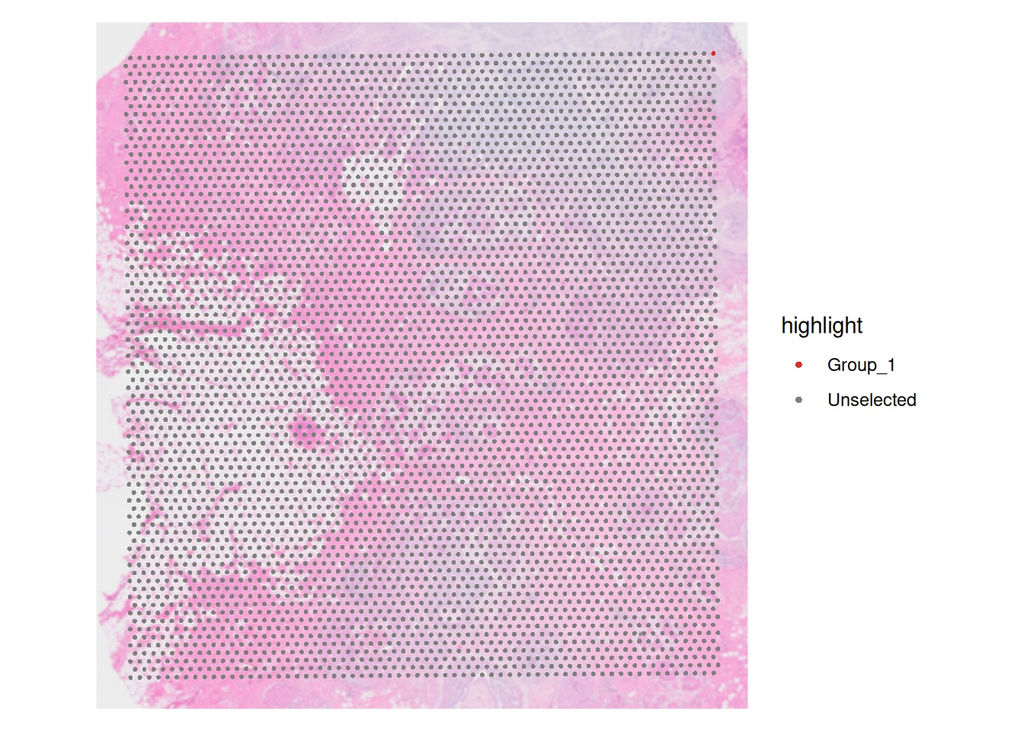

```r
# See where the spot with coordinates (0,0) maps (spot colored in red):
SpatialPlot(vis, cells.highlight =
              colnames(vis)[vis@meta.data$row == 0 &
                              vis@meta.data$col == 0 ])
```

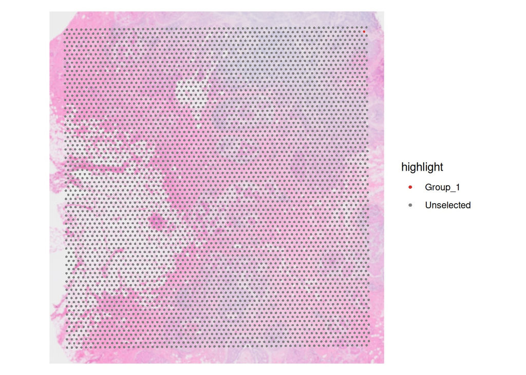

```r
# can you see it in the upper right corner?
# Because of how spots are disposed, the one right below is not (1,0) but (1,1):
SpatialPlot(vis, cells.highlight =
              colnames(vis)[vis@meta.data$row == 1 &
                              vis@meta.data$col == 1 ])
```

```r
# and the one further below will be (2,0) etc.
```

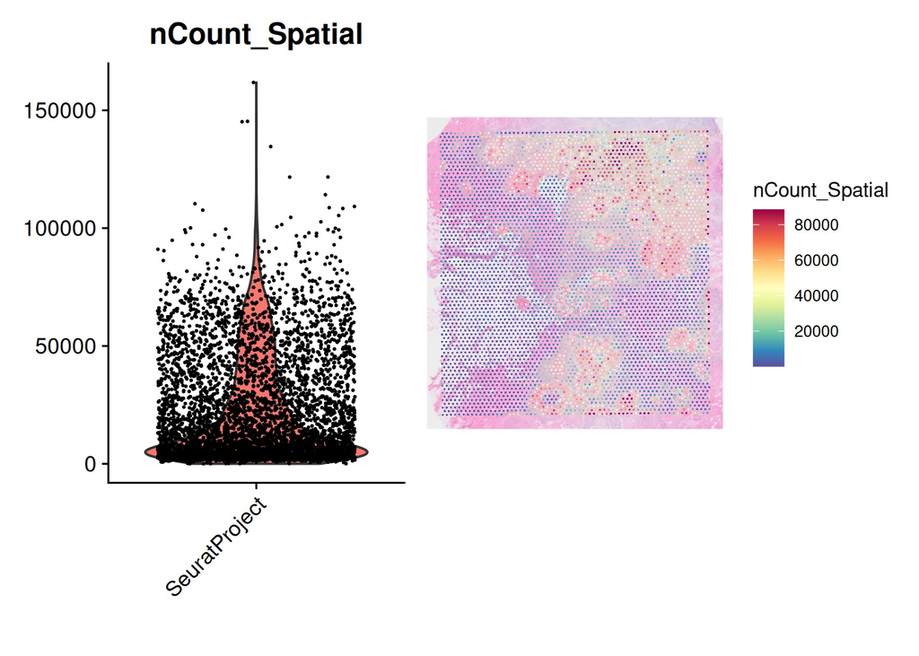

```r
# Visualize basic QC metrics
plot1 <- VlnPlot(vis, features = "nCount_Spatial", pt.size = 0.1, group.by="orig.ident") + NoLegend() + xlab("")
plot2 <- SpatialFeaturePlot(vis, features = "nCount_Spatial", max.cutoff = "q99") + theme(legend.position = "right")
# using the 99th quantile cutoff to avoid having the maximum be set by few outlier spots
plot3 <- VlnPlot(vis, features = "nFeature_Spatial", pt.size = 0.1, group.by="orig.ident") + NoLegend() + xlab("")
plot4 <- SpatialFeaturePlot(vis, features = "nFeature_Spatial") + theme(legend.position = "right")
wrap_plots(plot1, plot2)
```

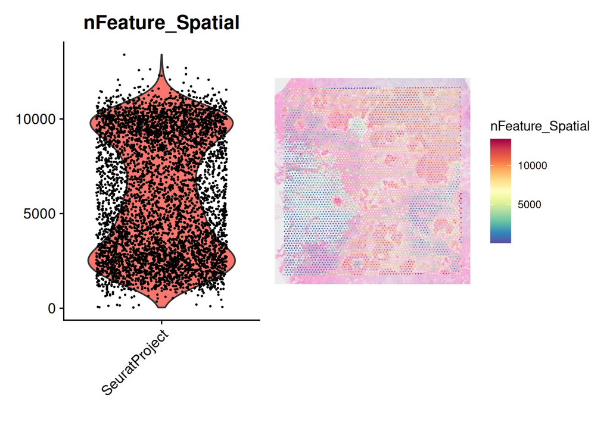

```r
wrap_plots(plot3, plot4)
```

```r
# 'nFeature_Spatial' are the number of genes detected expressed in each spot,
# 'nCount_Spatial' are the number of UMIs (unique molecular identifiers) detected in each spot, i.e. the number of transcripts.
```

#### Spatially variable features

Proceed with the Seurat normalization first, then rank spatially variable (SV) genes.

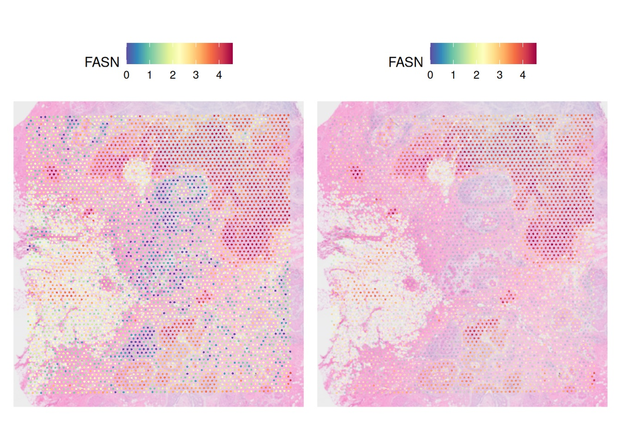

```r
# Newer version of the future package is limited to 500 MB in its size limit for the functions
# We up it to 1 GB
options(future.globals.maxSize = 1024 * 1024^2)

# Use regularized negative binomial regression to normalize UMI count data, see
# ?SCTransform for details.
vis <- SCTransform(vis, assay = "Spatial", return.only.var.genes=FALSE, verbose = FALSE)

# Now we can observe transcripts across the tissue
# e.g. FASN (Fatty Acid Synthase), high in the invasive tumor
p1 <- SpatialFeaturePlot(vis, features = "FASN") #, pt.size.factor = 1)
# use 'alpha' to change the opacity of the spots.
# Provide as a vector specifying the min and max for SpatialFeaturePlot,
# and see the tissue image below when a spot is outside range.
# For SpatialDimPlot, provide a single alpha value for each plot.
p2 <- SpatialFeaturePlot(vis, features = "FASN", alpha = c(0.1, 1))
p1 + p2
```

Spatially variable genes are genes whose expression distributions display significant dependence on their spatial locations. They might be different from the top highly variable genes. E.g. compare https://www.sc-best-practices.org/_images/svg.jpeg.

Also see: https://satijalab.org/seurat/articles/spatial_vignette.html#identification-of-spatially-variable-features-1

Rank the top 1000 highly variable genes based on how spatially variable their expression is.

Note that:

- here we decide to test these, and not all expressed genes (for simplicity);
- one can also specify only specific genes of interest to be ranked;
- instead of genes, one can also rank cell types by how well they correlate with their spatial location (once cell type probabilities are assigned to spots - we will see this next time).

```r
vis <- FindSpatiallyVariableFeatures(vis, assay = "SCT", features = VariableFeatures(vis)[1:1000],
                                    selection.method = "moransi") # ~2 min of computation
```

```
## Computing Moran's I
```

```
## Found more than one class "dist" in cache; using the first, from namespace 'spam'
```

```
## Also defined by 'BiocGenerics'
```

```
## Found more than one class "dist" in cache; using the first, from namespace 'spam'
```

```
## Also defined by 'BiocGenerics'
```

```r
top.sv.features <- SpatiallyVariableFeatures(vis, method = "moransi")[1:4]
####! While this is the normal way to do it, I got xtfrm error here in the past!
# There is a workaround posted on Seurat GitHub so we use that function:
#https://github.com/satijalab/seurat/issues/7422
# I am leaving the solution below, in case above doesn't work.

# SpatiallyVariableFeatures_workaround <- function(object, assay="SCT", selection.method = "moransi") {
#   #' This is work around function to replace SeuratObject::SpatiallyVariableFeatures function.
#   #' return ranked list of Spatially Variable Features
#
#   # Check if object is a Seurat object
#   if (!inherits(object, "Seurat")) {
#     stop("object must be a Seurat object")
#   }
#
#   # Check if assay is a valid assay
#   if (!assay %in% names(object@assays)) {
#     stop("assay must be a valid assay")
#   }
#
#   # Extract meta.features from the specified object and assay
#   data <- object@assays[[assay]]@meta.features
#
#   # Select columns starting with the provided col_prefix
#   moransi_cols <- grep(paste0("^", selection.method), colnames(data), value = TRUE)
#
#   # Filter rows where "moransi.spatially.variable" is TRUE
#   filtered_data <- data[data[[paste0(selection.method, ".spatially.variable")]], moransi_cols]
#
#   # Sort filtered data by "moransi.spatially.variable.rank" column in ascending order
#   sorted_data <- filtered_data[order(filtered_data[[paste0(selection.method, ".spatially.variable.rank")]]), ]
#
#   # Return row names of the sorted data frame
#   rownames(sorted_data)
# }
```

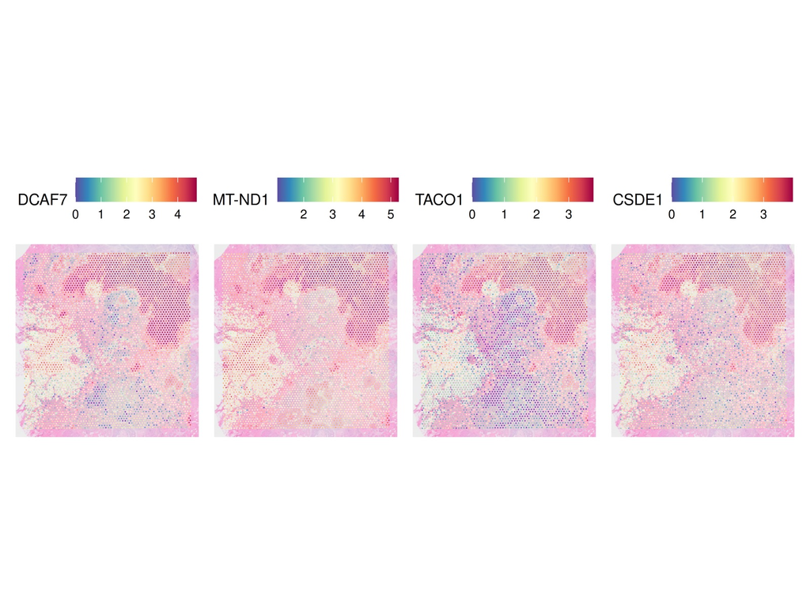

```r
# top.sv.features <- SpatiallyVariableFeatures_workaround(vis, selection.method = "moransi")[1:4]
SpatialFeaturePlot(vis, features = top.sv.features, ncol = 4)
```

```r
# Top ones map to an area that is also rich in mitochondrial transcripts (e.g. 'MT-ND1')
```

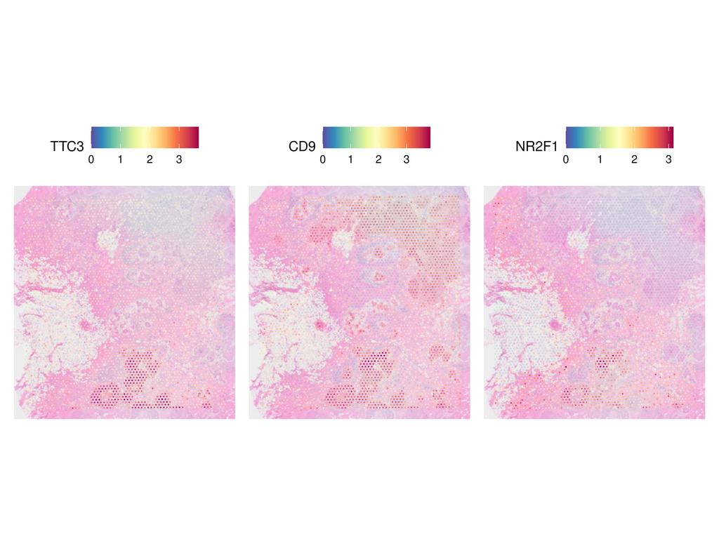

```r
# Plot some from further down in the list, you can see the spatial 'cohesion' slowly reduces.
SpatialFeaturePlot(vis, features = SpatiallyVariableFeatures(vis, method = "moransi")[100:102],
                   alpha = c(0.1, 1))
```

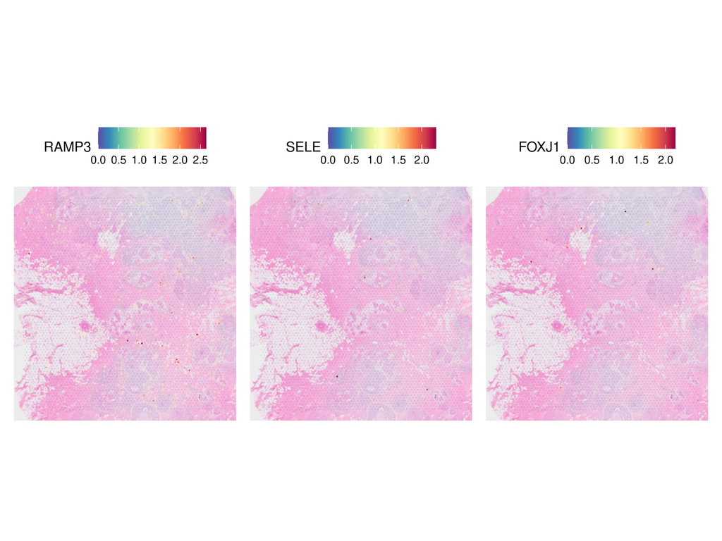

```r
# The 1000 genes are ordered from best to least spatially variable, and since we
# asked for so many, the bottom ones are actually rather scattered:
SpatialFeaturePlot(vis, features = SpatiallyVariableFeatures(vis, method = "moransi")[998:1000],
                  alpha = c(0.1, 1))
```

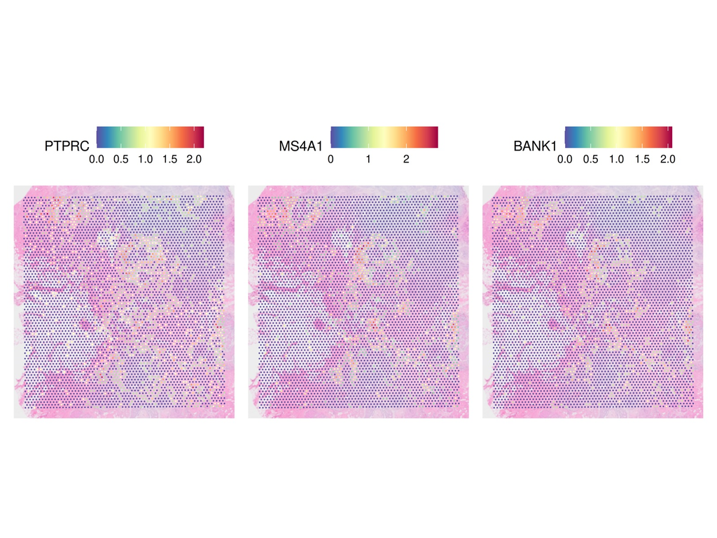

```r
# In a tissue such this, among the spatially scattered features,
# we can often expect the genes for immune cells:
# E.g. check PTPRC (codes for CD45, general immune cell marker) and
# MS4A1 (codes for CD20 B cells), BANK1 (codes for a scaffold protein in B cells)
SpatialFeaturePlot(vis, features = c("PTPRC", "MS4A1", "BANK1"))
```

Now treat spots as single cells and cluster them by their expression profile.

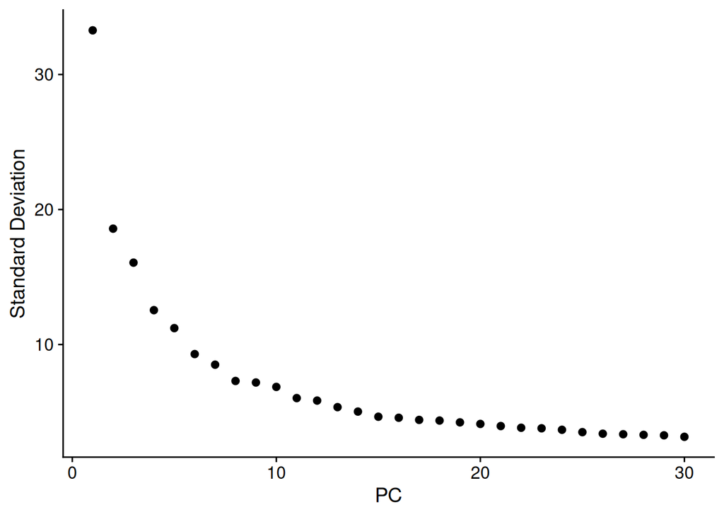

```r
vis <- RunPCA(vis, assay = "SCT", verbose = FALSE)
ElbowPlot(vis, ndims = 30)
```

```r
# Looks like 11 or 12 is good, how different would it be if I picked those?
vis <- FindNeighbors(vis, reduction = "pca", dims = 1:30)
vis <- FindClusters(vis, verbose = FALSE, resolution = 0.2)

# check number of clusters and number of assigned spots to each of those with:
table(vis$seurat_clusters)
```

```
##
##    0    1    2    3    4    5    6
## 1546 1449  923  344  325  250  155
```

```r
# Define the cluster markers at this resolution
all.markers.vis.res0.2 <- FindAllMarkers(vis, logfc.threshold = 0.5, only.pos = T)
# Optionally you can save the markers
# save(all.markers.vis.res0.2, file = "exercise_results/2/all.markers.vis_res0.2.RData")
# to load it again
# load("exercise_results/2/all.markers.vis_res0.2.RData")
```

Run non-linear dimensional reduction (UMAP)

```r
vis <- RunUMAP(vis, reduction = "pca", dims = 1:30)
```

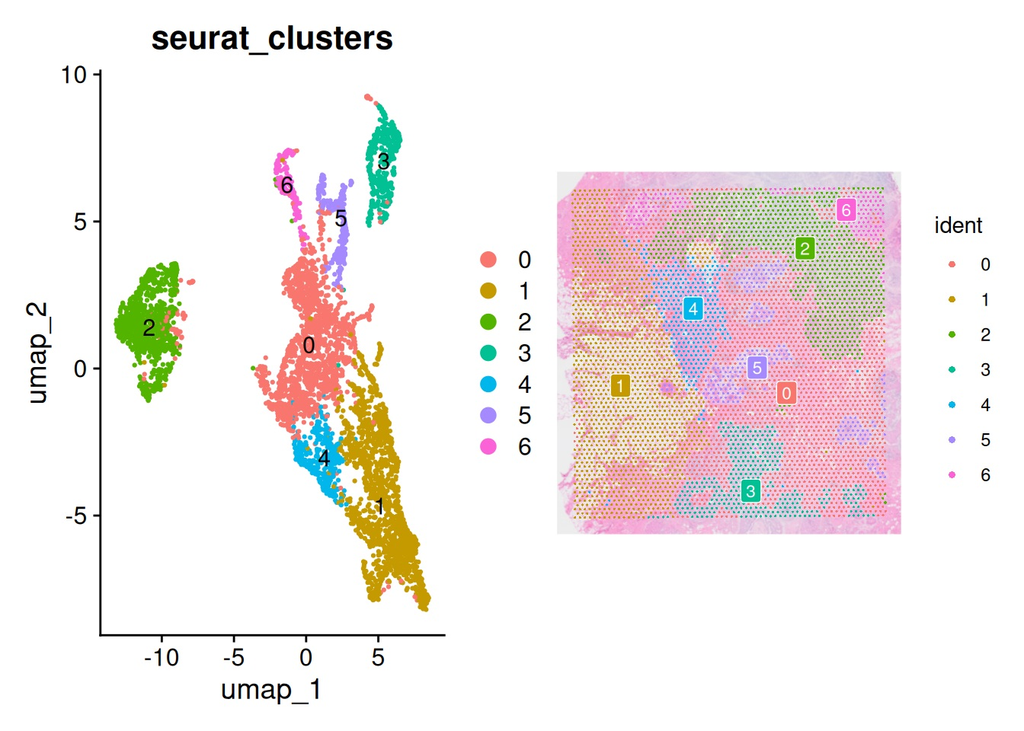

```r
# Plot the identified clusters on top of the UMAP representation:
p1 <- DimPlot(vis, reduction = "umap", group.by = "seurat_clusters", label=T)
p2 <- SpatialDimPlot(vis, label = TRUE, label.size = 3)
p1 + p2
```

```r
# Some clusters are well defined spatially, some are more scattered
# Also, bear in mind some will have a prevalence of 1 or few well defined cell types, and some will be more mixed.
```

Save your processed object.

```r
# Save this Seurat object.
save(vis, file = "vis_processed.RData")

# to load it again:
# load("exercise_results/2/vis_processed.RData")
```

Visualize the top 2 marker genes of each cluster found.

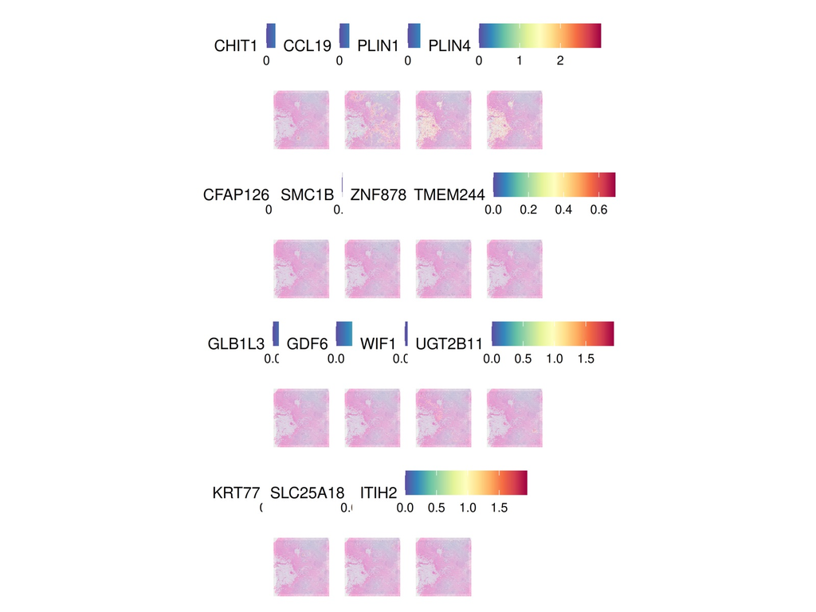

```r
# DEG (Differentially Expressed Genes)

top2markers_by_cluster <- all.markers.vis.res0.2 %>% group_by(cluster) %>%
  dplyr::slice_max(n = 2, order_by = avg_log2FC) %>% ungroup %>% select(gene) %>% unlist

SpatialFeaturePlot(object = vis, alpha = c(0.5, 1), ncol = 4,
                   features = top2markers_by_cluster )
```

#### Characterize the tissue

We can use the Xenium breast cancer panel (and its annotation) to help us characterize the tissue, its areas and its clusters (some might be useful, some not so much). Similarly, also your curated single cell annotation should help you do that (with a better resolution if you curated well enough some of the cell subtypes).

```r
# If needed, download again 10x Genomics's gene panel for human breast cancer (280 genes) and save it with the other files:
#
 download.file(url="https://cf.10xgenomics.com/supp/xenium/panels/hBreast_v1.csv",
               destfile = "10x_human_breast_cancer_gene_panel.csv")

panel <- read.csv("10x_human_breast_cancer_gene_panel.csv", header = F)[,c(1,5)] %>% setNames(., c("gene", "annotation"))

# Are any of the spatially variable genes in common with those in the Xenium panel?

SpatiallyVariableFeatures(vis, method = "moransi")[
SpatiallyVariableFeatures(vis, method = "moransi") %in% panel$gene]
```

```
##   [1] "FASN"     "ERBB2"    "EPCAM"    "FOXA1"    "ANKRD30A" "ADH1B"
##   [7] "MLPH"     "CXCL12"   "SCD"      "KRT7"     "CEACAM6"  "ADIPOQ"
##  [13] "CD9"      "POSTN"    "MMP2"     "LPL"      "CCDC80"   "GATA3"
##  [19] "SFRP4"    "ABCC11"   "LUM"      "MYO5B"    "FBLN1"    "PDK4"
##  [25] "TFAP2A"   "KRT8"     "CDH1"     "S100A14"  "IGF1"     "C1QA"
##  [31] "SFRP1"    "TACSTD2"  "KRT14"    "MZB1"     "CRISPLD2" "PTGDS"
##  [37] "KRT23"    "MMP12"    "PDGFRA"   "C1QC"     "CD14"     "AGR3"
##  [43] "SERPINA3" "DSP"      "KRT5"     "LYZ"      "OPRPN"    "KRT6B"
##  [49] "IL7R"     "LRRC15"   "TRAC"     "AQP1"     "PDGFRB"   "PTN"
##  [55] "LTB"      "CXCR4"    "MYLK"     "CD163"    "ITM2C"    "ZEB2"
##  [61] "S100A4"   "MYBPC1"   "MS4A1"    "ACTG2"    "SELL"     "FGL2"
##  [67] "CCL5"     "IL2RG"    "DPT"      "CYTIP"    "CAV1"     "MRC1"
##  [73] "CD4"      "APOC1"    "MYH11"    "CD68"     "CD79A"    "PRDM1"
##  [79] "ACTA2"    "CD3E"     "BANK1"    "EGFR"     "OXTR"     "GPR183"
##  [85] "TCF4"     "FCER1A"   "ITGAX"    "CCR7"     "AIF1"     "TCF7"
##  [91] "FCER1G"   "DSC2"     "PECAM1"   "PTPRC"    "CD69"     "ADGRE5"
##  [97] "GLIPR1"   "VWF"      "CD27"     "PPARG"    "KLRB1"    "CAVIN2"
## [103] "EGFL7"    "GNLY"     "MMP1"     "CD93"     "KIT"      "CPA3"
## [109] "S100A8"   "CTSG"
```

```r
# 100+ genes are in common.
```

Use Seurat’s AddModuleScore again to map the possible presence of general cell types across the tissue slice (remember that each spot contains multiple cells, so it will be less precise than with the single cell dataset).

```r
# Check if any gene in the panel is not present in the dataset:
panel$gene[!panel$gene %in% rownames(vis)]
```

```
## [1] "AKR1C1"   "ANGPT2"   "APOBEC3B" "TPSAB1"
```

```r
# Do we still have other genes in the panel for the same cell types? How many?
panel %>% filter(annotation == panel$annotation[!panel$gene %in% rownames(vis)]) %>% select(annotation) %>% table
```

```
## annotation
##       Breast cancer   Endothelial cells Smooth muscle cells
##                   7                   2                   4
```

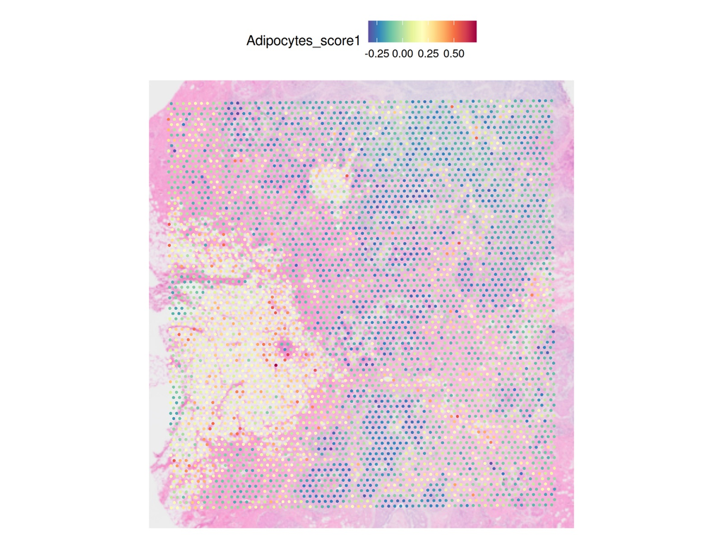

```r
# Subset the panel for the genes in the dataset, and use that to define an approximate score for each cell type:
panel <- panel %>% filter(gene %in% rownames(vis))

# extract the list of cell types in the annotation column
panel_cell_types <- panel$annotation %>% unique


# Explore the 'AddModuleScore' function from Seurat, and try to apply it for the annotation of 'Adipocytes'
tmp <- AddModuleScore(vis, features = (panel %>% filter(annotation == "Adipocytes") %>% select(gene) %>% as.list), name = "Adipocytes_score")

# Plot the score. Note: Seurat adds a number (here '1') at the end of the name we've chosen for the score,
# to avoid ambiguous duplicates when running multiple modules with the same name
SpatialPlot(tmp, features = "Adipocytes_score1")
```

```r
# Repeat the same for the all the annotated cell types in the panel, in an automated way.
# As AddModuleScore accepts a list of vectors to score multiple expression programs at once, where 'each entry should be a vector of feature names' (i.e. of gene names),
# reshape the panel dataframe as a named list of vectors, one vector for each cell type annotation:
annotation_list <- panel %>% select(gene, annotation) %>% group_by(annotation) %>% # this groups each gene to the cell type annotation
                            group_map(~.$gene) %>% # this creates the list of vectors, where each vector is the set of genes for a cell type
                            setNames(., panel %>% group_by(annotation) %>% group_keys() %>% pull(1)) # this names each vector in the list with the matching cell type label

# The warning about group_keys() can be ignored, check the output:
str(annotation_list)
```

```
## List of 19
##  $ Adipocytes                : chr [1:21] "ADH1B" "ADIPOQ" "ANKRD29" "CAVIN2" ...
##  $ B cells                   : chr [1:26] "ANKRD28" "APOBEC3A" "BANK1" "C2orf42" ...
##  $ Breast cancer             : chr [1:32] "ABCC11" "AR" "CAV1" "CCND1" ...
##  $ Breast glandular cells    : chr [1:52] "ADAM9" "AGR3" "ALDH1A3" "AQP3" ...
##  $ Breast myoepithelial cells: chr [1:15] "ACTG2" "C6orf132" "DSP" "DST" ...
##  $ Dendritic cells           : chr [1:9] "ADGRE5" "CD83" "CLEC9A" "FCER1A" ...
##  $ Endothelial cells         : chr [1:10] "AKR1C3" "AQP1" "CD93" "ESM1" ...
##  $ Epithelial cells          : chr [1:6] "ANKRD30A" "EPCAM" "KRT14" "KRT8" ...
##  $ Fibroblasts               : chr [1:14] "CCDC80" "DPT" "FBLN1" "IGF1" ...
##  $ Immune cells              : chr "PTPRC"
##  $ Macrophages               : chr [1:26] "AIF1" "APOC1" "BASP1" "C1QA" ...
##  $ Mast cells                : chr [1:2] "CPA3" "CTSG"
##  $ Monocytes                 : chr [1:3] "CD14" "FCGR3A" "S100A8"
##  $ Myeloid cells             : chr "ITGAM"
##  $ NK cells                  : chr [1:8] "CD247" "FCER1G" "GNLY" "KLRD1" ...
##  $ Neutrophils               : chr "CEACAM8"
##  $ Plasma cells              : chr "TNFRSF17"
##  $ Smooth muscle cells       : chr [1:13] "ACTA2" "AVPR1A" "CCL8" "CRISPLD2" ...
##  $ T cells                   : chr [1:35] "CCL5" "CCR7" "CD274" "CD3E" ...
```

```r
# substitute the spaces with underscores in the cell type labels
names(annotation_list) <- names(annotation_list) %>% stringr::str_replace_all(pattern = " ", replacement = "_")

tmp <- AddModuleScore(vis,
                      features = annotation_list,
                        name = paste0(names(annotation_list) , "_score")) # add 'score_' at the beginning of the name of the score


# Observe how the score for each cell has been added to the metadata of the Seurat object
str(tmp@meta.data)
```

```
## 'data.frame':    4992 obs. of  28 variables:
##  $ orig.ident                       : chr  "SeuratProject" "SeuratProject" "SeuratProject" "SeuratProject" ...
##  $ nCount_Spatial                   : num  12675 7886 32614 7484 6694 ...
##  $ nFeature_Spatial                 : int  6022 3979 9017 4183 3693 2948 7736 7716 9179 8114 ...
##  $ row                              : int  0 76 47 69 49 71 28 51 24 12 ...
##  $ col                              : int  122 22 71 7 43 127 86 41 6 10 ...
##  $ nCount_SCT                       : num  12599 12396 14012 12325 12423 ...
##  $ nFeature_SCT                     : int  5795 3938 6268 4149 3826 3870 6178 6419 5703 6214 ...
##  $ SCT_snn_res.0.2                  : Factor w/ 7 levels "0","1","2","3",..: 2 1 6 1 1 2 5 3 3 1 ...
##  $ seurat_clusters                  : Factor w/ 7 levels "0","1","2","3",..: 2 1 6 1 1 2 5 3 3 1 ...
##  $ Adipocytes_score1                : num  0.0461 -0.05 0.0542 -0.0859 0.0686 ...
##  $ B_cells_score2                   : num  -0.05409 -0.01583 -0.12946 0.00956 -0.04297 ...
##  $ Breast_cancer_score3             : num  0.194 0.248 0.136 0.207 0.185 ...
##  $ Breast_glandular_cells_score4    : num  -0.1312 -0.0355 0.2751 0.1952 0.0127 ...
##  $ Breast_myoepithelial_cells_score5: num  -0.158 -0.139 0.6266 -0.0623 -0.0579 ...
##  $ Dendritic_cells_score6           : num  -0.1182 -0.1084 0.2523 0.0781 -0.1232 ...
##  $ Endothelial_cells_score7         : num  0.11224 -0.16297 0.17394 0.04276 0.00625 ...
##  $ Epithelial_cells_score8          : num  -0.6167 -0.1023 0.5356 0.1026 0.0791 ...
##  $ Fibroblasts_score9               : num  0.7928 1.0032 -0.0347 0.7503 1.0172 ...
##  $ Immune_cells_score10             : num  -0.261 0.568 0.482 -0.159 -0.203 ...
##  $ Macrophages_score11              : num  0.0952 0.1801 0.1553 0.3968 0.1249 ...
##  $ Mast_cells_score12               : num  0.69 0.913 -0.247 0.799 0.744 ...
##  $ Monocytes_score13                : num  0.194 0.27 0.225 0.204 -0.607 ...
##  $ Myeloid_cells_score14            : num  0.4788 -0.127 -0.1312 -0.104 -0.0867 ...
##  $ NK_cells_score15                 : num  0.0369 0.14782 -0.0607 0.26185 -0.00276 ...
##  $ Neutrophils_score16              : num  0 0 0 0 0 0 0 0 0 0 ...
##  $ Plasma_cells_score17             : num  -0.1964 0.6169 -0.2461 0.9808 -0.0555 ...
##  $ Smooth_muscle_cells_score18      : num  0.083 0.227 0.041 0.201 0.061 ...
##  $ T_cells_score19                  : num  -0.1025 0.0653 -0.1348 0.1475 -0.1147 ...
```

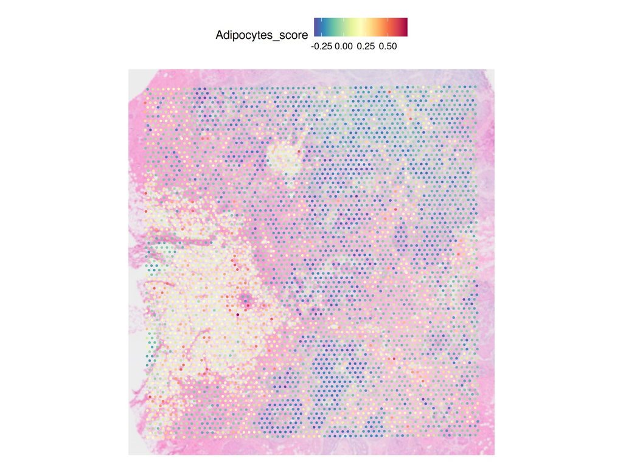

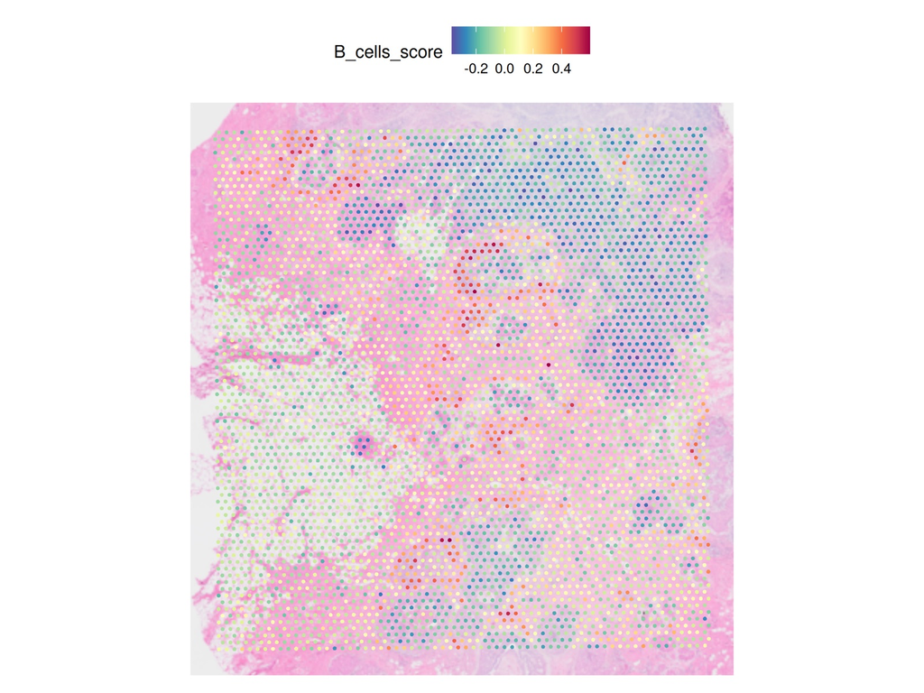

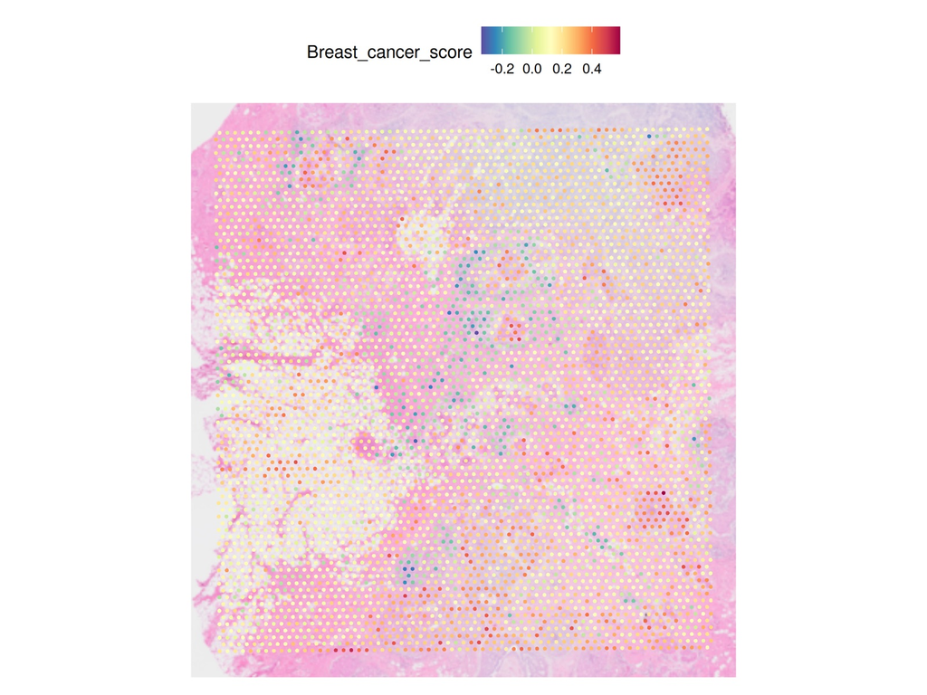

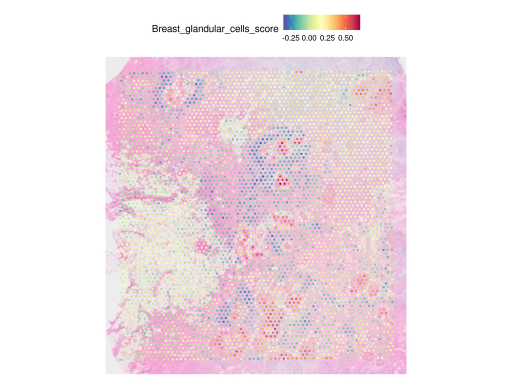

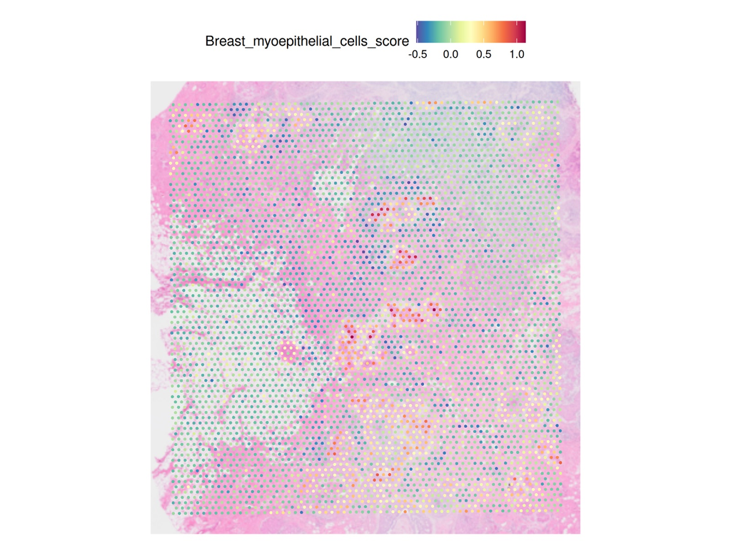

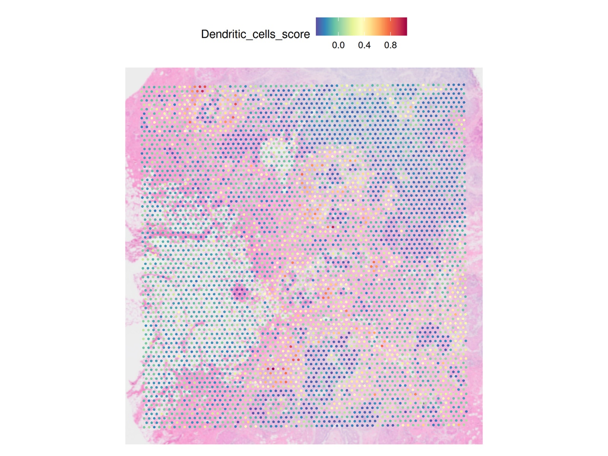

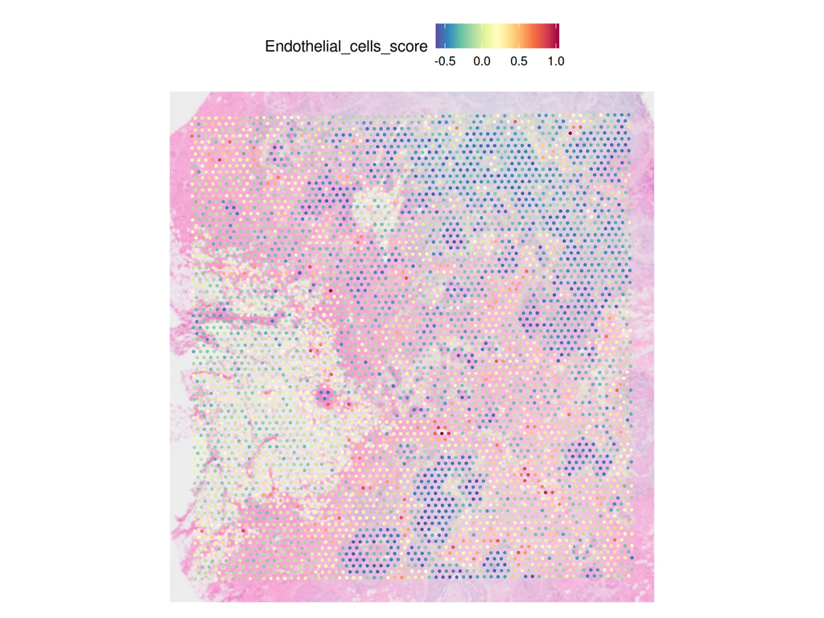

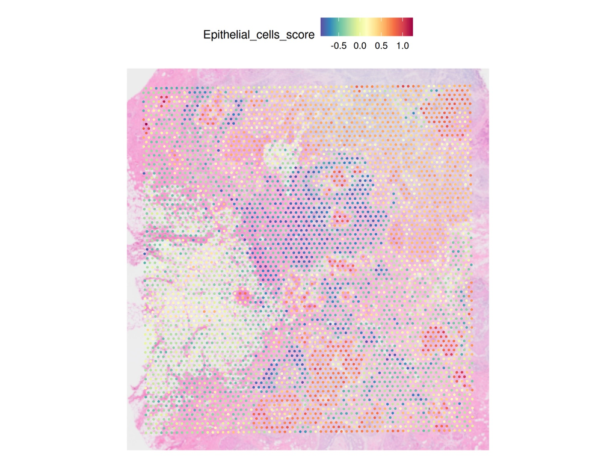

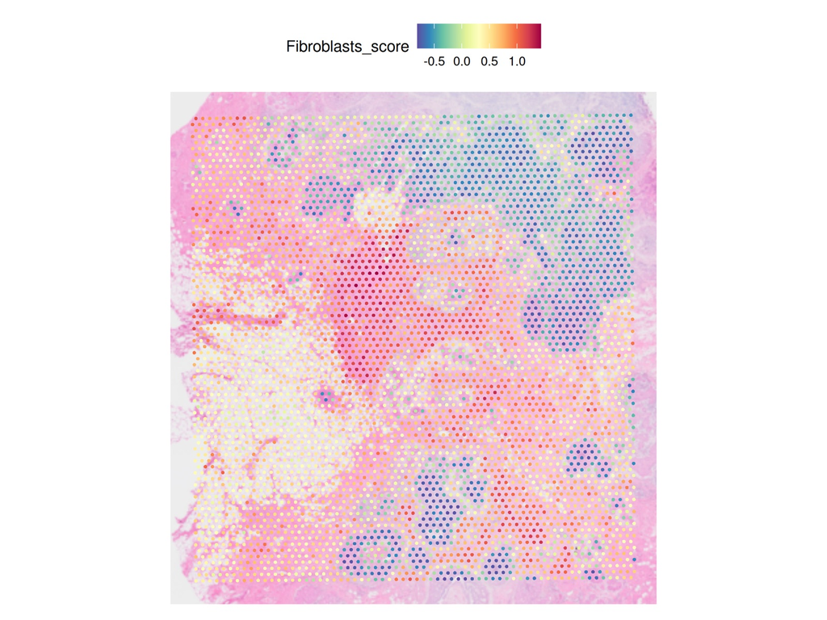

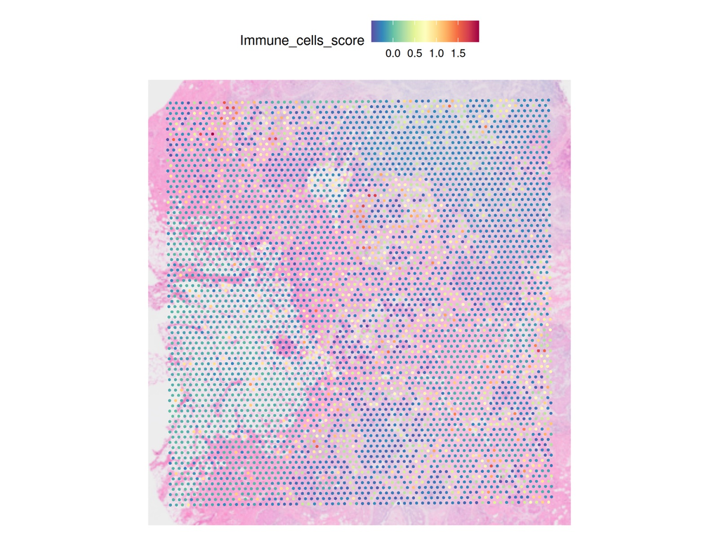

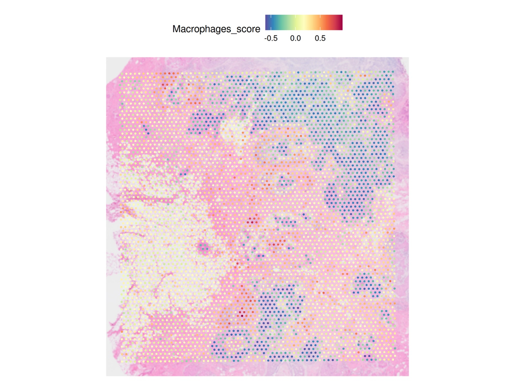

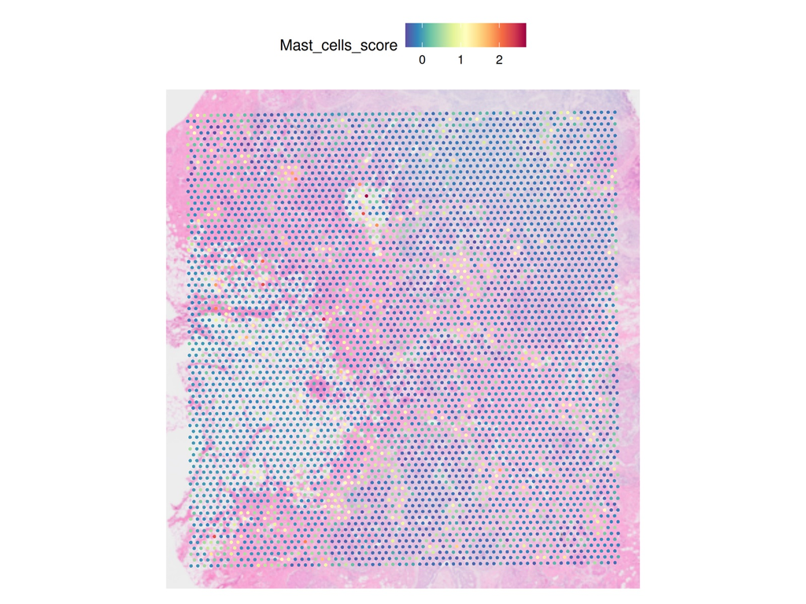

[7 more figures not shown]

```r
# for aesthetics, we can remove the trailing number Seurat adds to the score label:
names(tmp@meta.data) <- names(tmp@meta.data) %>% stringr::str_replace(pattern = "_score.*", "_score")

# Plot the scores obtained:
features <- names(tmp@meta.data) %>% grep("_score", ., value = TRUE)
for (f in features) {
  print(SpatialPlot(tmp, features = f))
}
```

```r
#rm(tmp) # remove before re-running, or the scores will be saved multiple times
```

The scores for each cell depend on the composition of the dataset, which might not be intuitive at first, and it’s important to remember when you use it to make assumptions about your data.

You can repeat the same creating your own panel of top marker genes for the other cell types/states you defined in your annotation, and use them in the same way to help you characterize the tissue (for cell types with just 2-3 specific markers, you can also just plot them individually).

#### Drawing from the various approaches that we saw and from your curated single-cell annotation, try to contextualize spatially (choose markers/scores to plot and comment if and how well they are spatially located) where are the cell types of the following:

(You can also check the high-resolution H&E image, e.g. `spatial/tissue_hires_image.png`)

1 - the stroma

2 - the invasive tumor

3 - the luminal epithelium

4 - the myoepithelial layer(s)

5 - three immune cell types

6 - any other feature/cell type you characterized and think it could be interesting to check spatially.